# Volcanic Eruptions and Resulting Deaths

## Introduction

Volcanoes have been erupting ever since the earth's creation, and humnaity has only been around for a fraction of that time to witness these eruptions. Volcanic eruptions tend to be very dangerous and cause mass distruction, and I will use the `significant-volcanic-eruption-database.csv` from [opendatasoft](https://public.opendatasoft.com/explore/dataset/significant-volcanic-eruption-database/information/) and thats also available from NOAA to investigate the 835 recorded volcanic eruptions. This dataset only includes information about the volcanic eruptions themselves. Sadly, it doesn't include data that says whether or not the area the volcano erupted in was populated or not.

In this notebook I will look into questions about deaths that result from volcanoes and what makes volcanoes destructive. What volcano type typically has the highest explosivity index? Did more deaths occur from volcanoes in the past then they do now? Finally, is it possible predict the range of deaths that would occur from a volcanic explosion, using the data about the volcanic eruption?

## Data Explanation and Exploration

In this section I will load the data and explain what the dataset is. Then I will wrangle the data, a lot of the data within the original csv is tidy and ready for exploration, but some minor adjustments need to be made. Afterwards, I will begin to explore the data with visualizations and summary tables/statistics. These explorations may help me to start to answer the research questions above.

```python
# importing the necessary libraries
import numpy as np
import pandas as pd
import altair as alt
from matplotlib import pyplot as plt


alt.data_transformers.enable("vegafusion")


from sklearn.tree import DecisionTreeClassifier, plot_tree

from sklearn.ensemble import RandomForestClassifier
from sklearn.datasets import make_classification


# Tools to split the dataset and validate the model
from sklearn.model_selection import train_test_split, cross_val_score

# Tools to validate the regression results using the "testing" portion
from sklearn.metrics import mean_squared_error, r2_score

# Tools to validate classification results
from sklearn.metrics import confusion_matrix, classification_report, RocCurveDisplay


data = pd.read_csv("../Data/significant-volcanic-eruption-database.csv", delimiter=";")
data
```

|  | Year | Month | Day | Flag Tsunami | Flag Earthquake | Volcano Name | Location | Country | Elevation | Volcano Type | ... | Total Effects : Missing Description | Total Effects : Injuries | Total Effects : Injuries Description | Total Effects : Damages in million Dollars | Total Effects : Damage Description | Total Effects : Houses Destroyed | Total Effects : Houses Destroyed Description | Coordinates | Earthquakes : Houses damaged Description | Total Effects : Houses Damaged Description |
| --- | --- | --- | --- | --- | --- | --- | --- | --- | --- | --- | --- | --- | --- | --- | --- | --- | --- | --- | --- | --- | --- |
| 0 | -141 | NaN | NaN | NaN | NaN | Etna | Italy | Italy | 3350 | Stratovolcano | ... | NaN | NaN | NaN | NaN | NaN | NaN | NaN | 37.734, 15.004 | NaN | NaN |
| 1 | 1262 | NaN | NaN | NaN | NaN | Katla | Iceland-S | Iceland | 1512 | Subglacial volcano | ... | NaN | NaN | NaN | NaN | NaN | NaN | NaN | 63.63, -19.05 | NaN | NaN |
| 2 | 1300 | 7.0 | 11.0 | NaN | NaN | Hekla | Iceland-S | Iceland | 1491 | Stratovolcano | ... | NaN | NaN | NaN | NaN | NaN | NaN | NaN | 63.98, -19.7 | NaN | NaN |
| 3 | 1331 | 12.0 | NaN | NaN | NaN | Aso | Kyushu-Japan | Japan | 1592 | Caldera | ... | NaN | NaN | NaN | NaN | NaN | NaN | NaN | 32.88, 131.1 | NaN | NaN |
| 4 | 1714 | 6.0 | 30.0 | Tsunami | NaN | Vesuvius | Italy | Italy | 1281 | Complex volcano | ... | NaN | NaN | NaN | NaN | NaN | NaN | NaN | 40.821, 14.426 | NaN | NaN |
| ... | ... | ... | ... | ... | ... | ... | ... | ... | ... | ... | ... | ... | ... | ... | ... | ... | ... | ... | ... | ... | ... |
| 830 | 1979 | 7.0 | 5.0 | NaN | NaN | Etna | Italy | Italy | 3350 | Stratovolcano | ... | NaN | 23.0 | Few (~1 to 50 deaths) | NaN | NaN | NaN | NaN | 37.734, 15.004 | NaN | NaN |
| 831 | 1982 | 5.0 | 17.0 | NaN | NaN | Galunggung | Java | Indonesia | 2168 | Stratovolcano | ... | NaN | NaN | NaN | 15.0 | SEVERE (~>$5 to $24 million) | NaN | NaN | -7.25, 108.05 | NaN | NaN |
| 832 | 1988 | 7.0 | 6.0 | NaN | NaN | Arenal | Costa Rica | Costa Rica | 1657 | Stratovolcano | ... | NaN | NaN | NaN | NaN | NaN | NaN | NaN | 10.463, -84.703 | NaN | NaN |
| 833 | 2005 | 11.0 | 24.0 | NaN | NaN | Karthala | Indian O-W | Comoros | 2361 | Shield volcano | ... | NaN | NaN | NaN | NaN | LIMITED (roughly corresponding to less than $1... | NaN | NaN | -11.75, 43.38 | NaN | NaN |
| 834 | 2010 | 12.0 | 28.0 | NaN | NaN | Tengger Caldera | Java | Indonesia | 2329 | Stratovolcano | ... | NaN | NaN | NaN | NaN | NaN | NaN | NaN | -7.942, 112.95 | NaN | NaN |

835 rows × 35 columns

```python
data.info()
```

```
<class 'pandas.core.frame.DataFrame'>
RangeIndex: 835 entries, 0 to 834
Data columns (total 35 columns):
 #   Column                                        Non-Null Count  Dtype
---  ------                                        --------------  -----
 0   Year                                          835 non-null    int64
 1   Month                                         708 non-null    float64
 2   Day                                           647 non-null    float64
 3   Flag Tsunami                                  145 non-null    object
 4   Flag Earthquake                               67 non-null     object
 5   Volcano Name                                  835 non-null    object
 6   Location                                      835 non-null    object
 7   Country                                       835 non-null    object
 8   Elevation                                     835 non-null    int64
 9   Volcano Type                                  835 non-null    object
```

[output cut: 27 more lines]

Looking at column list above, the data has 35 columns and 835 rows. Each row represents a single volcanic eruption in history. Some key data within this dataset are the eruption date, the volcano type, location, explosivity index, data on the eruptions effects, and wheather or not a tsunami or an eathquake occurred with the eruption.

As you can see, this data is in pretty tidy shape! All the data types are the the correct and necessary type. As you can see, there are a couple of columns that only hold null values. These columns are unnecessary, so I will drop them. If we were to use the coordinates column in our analysis, I would suggest that separate that column into latitude and longnitude and change their data type to a float data type. I feel like a lot of the columns could have better names, because the columns that include the word "description" actually hold data that describes the range category of that column. So, I will want to rename some columns to fit their data better. One issue with this dataset, is that it offers no insight as to if the volcano was in an inhabited area by humans or not. Not having this data may make my analyses harder to interpret, but the information I gain from my analyses without that data will still hold value.

```python
data = data.dropna(axis=1, how='all') # getting rid of columns with all null values
data = data.rename(columns={"Volcano : Deaths Description":"Vol_Deaths_Range",
                            "Volcano : Missing Description":"Vol_Missing_Range",
                            "Volcano : Injuries Description":"Vol_Injuries_Range",
                            "Volcano : Damage Description":"Vol_Damage_Range(in_M$)",
                            "Volcano : Houses destroyed Description":"Vol_Houses_Destroyed_Range",
                            "Total Effects : Deaths Description":"Tot_Deaths_Range",
                            "Total Effects : Missing Description":"Tot_Missing_Range",
                            "Total Effects : Injuries Description":"Tot_Injuries_Range",
                            "Total Effects : Damages in million Dollars":"Tot_Damage(in_M$)",
                            "Total Effects : Damage Description":"Tot_Damage_Range(in_M$)",
                            "Total Effects : Houses Destroyed Description":"Tot_Houses_Destroyed_Range",
                            "Total Effects : Houses Damaged Description":"Tot_Houses_Damaged_Range",
                            "Volcano : Deaths":"Vol_Deaths",
                            "Volcano : Missing":"Vol_Missing",
                            "Volcano : Injuries":"Vol_Injuries",
                            "Volcano : Damage (in M$)":"Vol_Damage(in_M$)",
                            "Volcano : Houses destroyed":"Vol_Houses_Destroyed",
                            "Total Effects : Deaths":"Tot_Deaths",
                            "Total Effects : Missing":"Tot_Missing",
                            "Total Effects : Injuries":"Tot_Injuries",
                            "Total Effects : Houses Destroyed":"Tot_Houses_Destroyed",
                            "Total Effects : Houses Damaged":"Total Effects : Houses Damaged Range"})
```

```python
#https://stackoverflow.com/questions/50375985/pandas-add-column-with-value-based-on-condition-based-on-other-columns

data.assign(Earthquake_Tsunami=lambda x: x['Flag Tsunami'])
data.loc[data['Flag Tsunami'] == "Tsunami",'Earthquake_Tsunami'] = 'Tsunami'
data.loc[data['Flag Earthquake'] == "Earthquake",'Earthquake_Tsunami'] = 'Earthquake'
data.loc[(data['Flag Earthquake'] == "Earthquake") & (data['Flag Tsunami'] == "Tsunami"),'Earthquake_Tsunami'] = 'both'
data.loc[(data['Flag Earthquake'] != "Earthquake") & (data['Flag Tsunami'] != "Tsunami"),'Earthquake_Tsunami'] = 'none'
```

Above, I am adding a new column to the dataframe that includes both the tsunami and earthquake data so I can better use this data in my prediction model

```python
# https://stackoverflow.com/questions/50375985/pandas-add-column-with-value-based-on-condition-based-on-other-columns
data['current'] = np.where(data['Year']>=1900, 'yes', 'no')
```

Above I am adding a current column, to divide my dataset into current and pervious eruptions so I can preform a hypothesis test on these categories later.

```python
data = data[['Year', 'Flag Tsunami', 'Flag Earthquake', 'Country', 'Elevation', 'Volcano Type', 'Volcanic Explosivity Index', 'Vol_Deaths', 'Vol_Deaths_Range', 'Tot_Deaths', 'Tot_Deaths_Range', 'Earthquake_Tsunami', 'current']]
data
```

|  | Year | Flag Tsunami | Flag Earthquake | Country | Elevation | Volcano Type | Volcanic Explosivity Index | Vol_Deaths | Vol_Deaths_Range | Tot_Deaths | Tot_Deaths_Range | Earthquake_Tsunami | current |
| --- | --- | --- | --- | --- | --- | --- | --- | --- | --- | --- | --- | --- | --- |
| 0 | -141 | NaN | NaN | Italy | 3350 | Stratovolcano | NaN | 40.0 | Few (~1 to 50 deaths) | 40.0 | Few (~1 to 50 deaths) | none | no |
| 1 | 1262 | NaN | NaN | Iceland | 1512 | Subglacial volcano | 3.0 | NaN | Few (~1 to 50 deaths) | NaN | Few (~1 to 50 deaths) | none | no |
| 2 | 1300 | NaN | NaN | Iceland | 1491 | Stratovolcano | 4.0 | NaN | NaN | 600.0 | Many (~101 to 1000 deaths) | none | no |
| 3 | 1331 | NaN | NaN | Japan | 1592 | Caldera | 2.0 | NaN | Few (~1 to 50 deaths) | NaN | Few (~1 to 50 deaths) | none | no |
| 4 | 1714 | Tsunami | NaN | Italy | 1281 | Complex volcano | NaN | NaN | NaN | NaN | NaN | Tsunami | no |
| ... | ... | ... | ... | ... | ... | ... | ... | ... | ... | ... | ... | ... | ... |
| 830 | 1979 | NaN | NaN | Italy | 3350 | Stratovolcano | 2.0 | 9.0 | Few (~1 to 50 deaths) | 9.0 | Few (~1 to 50 deaths) | none | yes |
| 831 | 1982 | NaN | NaN | Indonesia | 2168 | Stratovolcano | 4.0 | 68.0 | Some (~51 to 100 deaths) | 68.0 | Some (~51 to 100 deaths) | none | yes |
| 832 | 1988 | NaN | NaN | Costa Rica | 1657 | Stratovolcano | 3.0 | 1.0 | Few (~1 to 50 deaths) | 1.0 | Few (~1 to 50 deaths) | none | yes |
| 833 | 2005 | NaN | NaN | Comoros | 2361 | Shield volcano | NaN | NaN | Few (~1 to 50 deaths) | NaN | Few (~1 to 50 deaths) | none | yes |
| 834 | 2010 | NaN | NaN | Indonesia | 2329 | Stratovolcano | NaN | NaN | NaN | NaN | NaN | none | yes |

835 rows × 13 columns

```python
# Got this from
# https://scales.arabpsychology.com/stats/how-to-add-a-count-column-to-a-pandas-dataframe/
data['vol_type_erupt_count'] = data.groupby('Volcano Type')['Year'].transform('count')
```

## Statistical Analysis and Interpretation

```python
VolCount = data[['Volcano Type', "Country"]].groupby(['Volcano Type',]).nunique()
alt.Chart(VolCount, title="The Number of Countries Each Volcano Type is in").mark_line().encode(
    x=alt.X("Volcano Type:N"),
    y=alt.Y("Country:Q", title="Number of Countries")
).properties(
    height=200,
    width=600
)
```

[interactive chart not shown]

This is a line graph of the number of countries each type of volcano has a recorded eruption in. I was expecting there to be volcanoes that had more countries that they have had eruptions in based on their nature, for example, the subglacial volcano is only going to be in places where there are glaciers. I was very surprised to see that **stratovolcanoes** are in **over 35 different countries** and that the `volcano types are not more evely distributed around the world`. The second most common volcano is the caldera, in about 15 different countries. This data may make it hard to differentiate data when we are later making a prediction model.

```python
alt.Chart(data, title="The Number of Deaths Per Explosivity Index").mark_area().encode(
    x=alt.X("Volcanic Explosivity Index"),
    y=alt.Y("mean(Vol_Deaths):Q", title="Mean Deaths")
).properties(
    height=200,
    width=600
)
```

[interactive chart not shown]

This area plot of the volcanoes data set shows the relationship between the mean number of deaths and explosivity index. This graph behaves exactly as I thought it would. We don't see any real increase in deaths until we reach an explosivity index of 2.0. From that point on, the `mean amount of deaths` **increases exponentially** at each `explosivity index`. Going from around 0 at 2.0, to about 300-400 at 3.0, to around 1000 at 4.0, to around 2200 at 5.0, to 5500 at 6.0, to 11000 at 7.0. This shows that there is a correlation between the amount of deaths that result of a volcanic eruption and the volcanic explosivity index of that eruption.

```python
deaths = data.copy()
deaths.dropna(subset=['Vol_Deaths'], inplace=True)
toGroup = deaths[['Volcano Type', 'Vol_Deaths']].groupby('Volcano Type').mean()
toGroup = toGroup[toGroup['Vol_Deaths'] > 75]
toGroup.sort_values(by='Vol_Deaths', ascending=False)
# There were too many different volcano types on the graph below to the point I couldn't differentiate the colors
# that belonged to certain volcanoes, so I used this to choose which volcanoes would be most relevant.
# I also made this decision based off of which volcanoes showed up on the graph previously
```

| Volcano Type | Vol_Deaths |
| --- | --- |
| Caldera | 1071.633333 |
| Maar | 868.500000 |
| Tuff cone | 637.666667 |
| Stratovolcano | 480.120275 |
| Shield volcano | 223.653846 |
| Complex volcano | 214.928571 |
| Pyroclastic shield | 91.500000 |

```python
CY = data[['Country', 'Year']].groupby(['Country']).count()
CYdf = pd.DataFrame(CY)
CYdf = CYdf[CYdf.Year > 10]
CYdf.sort_values("Year", ascending=False)
#this will help with the interpretation of the graph below
```

| Country | Year |
| --- | --- |
| Indonesia | 194 |
| Japan | 135 |
| Italy | 58 |
| Iceland | 53 |
| United States | 49 |
| Philippines | 47 |
| Papua New Guinea | 40 |
| Ecuador | 23 |
| Chile | 20 |
| Russia | 20 |
| Guatemala | 19 |
| Vanuatu | 17 |
| New Zealand | 15 |
| Mexico | 12 |

```python
vols = data.copy()
vols = deaths[(deaths['Volcano Type'] == 'Caldera') | (deaths['Volcano Type'] == 'Tuff cone') |
              (deaths['Volcano Type'] == 'Stratovolcano') | (deaths['Volcano Type'] == 'Shield volcano') |
              (deaths['Volcano Type'] == 'Complex volcano') | (deaths['Volcano Type'] == 'Pyroclastic shield') |
              (deaths['Volcano Type'] == 'Maar')]

volg = vols[['Country', 'Volcano Type', 'Vol_Deaths']].groupby(['Country', 'Volcano Type']).mean()
vold = pd.DataFrame(volg)
vold = vold[vold.Vol_Deaths > 5]

DC = alt.Chart(vold, title="The Number of Deaths Per Country").mark_bar().encode(
    x=alt.X("Country:N"),
    y=alt.Y("Vol_Deaths:Q", title="Mean Deaths").scale(domain=(0,3000), clamp=True),
    color =alt.Color('Volcano Type:N')
).properties(
    height=400,
    width=1000
)

DCtext=alt.Chart(vold).mark_text(align='center', baseline='bottom', fontSize=12).encode(
    x=alt.X("Country:N"),
    y=alt.Y("Vol_Deaths:Q"),
    color=alt.Color('Volcano Type:N', legend=None, scale=alt.Scale(range=['black'])),
    text=alt.Text("Vol_Deaths:Q",format='.1f')
)

alt.layer(DC, DCtext).resolve_scale(color='independent')

# Text adjustment help from: https://stackoverflow.com/questions/61657741/altair-bar-chart-label-placement-and-formating
```

[interactive chart not shown]

This bar chart of the countries volcanoes data set shows the distributions of mean deaths per country, separated by the volcano type. This visualization really helps me see what countries have the highest mean deaths and it tells me which volcanoes produced them in each country. This dataset overwhelmingly shows that stratovolcanoes are the top contributors for high volume deaths, folloed by calderas, complex volcanoes, maars, shield volcanoes, tuff cones, and finally pyroclastic shields. This bar chart is scaled so we can see the separations of the volcano types, but they have labels, so we can see the extemely high bars' data. It is interesting to note, that the `countries with the highest experience with volcanoes, meaning the countries with the most volcanic eruptions recorded, have lower death counts than countries with less experience`. This may show that countries with higher experience may be better at dealing with volcanic eruptions than less experienced ones. There are significant size differences between countries volcano types deaths means, so this shows me that these variables can be used as predictors in my model.

```python
datav = data[data['vol_type_erupt_count'] > 2]
bar = alt.Chart(data, title="Volcano Type Versus Deaths: After Effects").mark_bar().encode(
    x=alt.X("Volcano Type:N"),
    y=alt.Y("mean(Tot_Deaths):Q").scale(domain=(0,3000), clamp=True).stack(None),
    color=alt.Color("Earthquake_Tsunami:N"),
    order=alt.Order(
      # Sort the segments of the bars by this field
      'mean(Tot_Deaths):Q',
      sort='descending'
    )
).properties(
    height=500,
    width=800
)

EEtext=alt.Chart(data).mark_text(align='left', baseline='bottom', dx=10, fontSize=12).encode(
    x=alt.X("Volcano Type:N"),
    y=alt.Y("mean(Tot_Deaths):Q"),
    color=alt.Color("Earthquake_Tsunami:N", legend=None),
    text=alt.Text("count(Year):Q",format='.1f')
)

EDtext=alt.Chart(data).mark_text(align='right', baseline='bottom', fontSize=13).encode(
    x=alt.X("Volcano Type:N"),
    y=alt.Y("mean(Tot_Deaths):Q"),
    color=alt.Color("Earthquake_Tsunami:N", legend=None),
    text=alt.Text("mean(Tot_Deaths):Q",format='.1f')
)

#bar + EEtext + EDtext
alt.layer(bar, EEtext, EDtext).resolve_scale(color='independent')
# ordering of segments: https://altair-viz.github.io/gallery/stacked_bar_chart_sorted_segments.html
```

[interactive chart not shown]

This bar plot of the volcanos dataset shows the distributions of deaths across the different types of volcanoes in the data, separated by wheteher or not a tsunami or earthquake happened afterwards. Out of the 14 volcano types presented, 10 show to have had tsunamis or earthquakes happen afterward. Out of those 10 types, `7 show that eruptions that have tsunamis or earthquakes happen with the eruption have higher mean deaths happen than eruptions by themselves`. Out of tsunamis, earthquakes, or both, `earthquakes tend to be the natural disaster that has the lower amounts of deaths`. I expected that having both natural disasters happen would cause the most deaths, in actuality, there are instances of both having the most deaths occur from different volcano types. The shield volcano is the only volcano type to produce more deaths from an eruption by itself, than having tsunamis or earthquakes occur with it. Overall, the means of each volcano type's natural disaster is different from all the others and shows that we could use the earthquake_tsunami column as a predictor to predict the range of deaths that occur from a volcanic eruption.

```python
alt.Chart(data, title="Explosivity Indexes of Different Volcano Types").mark_boxplot().encode(
    x=alt.X("Volcanic Explosivity Index:Q", title="Explosivity Index"),
    y=alt.Y("Volcano Type:N")
).properties(
    height=400,
    width=600
)
```

[interactive chart not shown]

This boxplot of the volcanoes data set shows the distributions of volcanic explosivity index across the different types of volcanoes in the data. Submarine volcanoes, tuff cones, volcanic fields,subglacial volcanoes, pyroclastic cones, maars, and crater rows do not have any data shown in the visualization, so that means that there is only 1 piece of data on them in the dataset. This shows that these types of volcanoes are either uncommon, or that they do not erupt very often, with my dataset, I cannot exactly tell which statement is true, but if it is that they do not erupt often, it can be concidered safe to live by one. Compound volcanoes and fizzure vents have the lowest median of a 1.5 explosivity index. Followed by calderas, complex volcanoes, lava domes, and shield volcanoes, which have a median explosivity index of 2.0. Next are stratovolcanoes and pyroclastic shields with a median of 3.0. Finally cinder cones have the highest median of a 3.5 explosivity index. Cinder cones and compound volcanoes have the smallest interquartile ranges, suggesting that their eruptions explosivity indexes stay pretty consistent. Calderas, pyroclastic shields, and lava domes have the highest IQR range, suggesting that their eruptions explosivity indexes varry a lot and it is hard to predict what explosivity index could occur from their eruptions. No volcano has a IQR that is completely separated from all the other volcanoes, suggesting that there is not a statistically significant difference in their eruptions explosivity indexes to each other. However, there are some volcanoes that have a statistically significant difference in their eruptions explosivity indexes, such as cinder cones, complex volcanoes, and compound volcanoes, which their indexes decreases respectively. Another example is fizzure vents and pyroclastic shields, where pyroclastic shields have a higher explosivity index. Overall the graph suggests that cinder cones, pyroclastic shields, stratovolcanoes, and sometimes calderas tend to have higher explosivity indexes, while compound volcanoes and fizzure vents have lower explosivity indexes.

```python
alt.Chart(data, title="Deaths Per Explosivity Index").mark_boxplot().encode(
    x=alt.X("Tot_Deaths:Q", title="Deaths").scale(domain=(0,4500), clamp=True),
    y=alt.Y("Volcanic Explosivity Index:N")
    #color=alt.Color("gender", legend=None)
).properties(
    height=200,
    width= 1000
)
```

[interactive chart not shown]

This boxplot of the volcano data set shows the distributions of deaths that occured from each volcanic explosivity index. Volcanoes with explosivity indexes of 0-3 relatively have the same medians of death, not really showing very much significant statistical difference between them. Volcanoes with explosivity index of 3 have a slightly higher interquartile range of 68, which means that these volcanoes with explosivity index of 3 have slightly higher variation of data and have slighly higher data points than the other lower explosivity indexes, which could be a slight differentiation point between the two. Volcanoes with explosivity indexes 4-6 have bigger interquartile ranges, which exponentially increase from explosivity index 4, with the smallest range, to index 5, then 6 with the largest interquartile range. Large interquartile ranges typically mean that there is a large spread within the data, which can show that their median may not be as accurate. The median deaths for each volcanic explosivity index increases from 4-6, with index 4 having a median of 74, 5 with 864, and 6 with 2000. Index 5's interquartile range overlaps with the interquartile ranges and the medians of indexes 4 and 6, which means that these ranges are not easily differentiated from one another. Indexes 4 and 6 do not have overlapping interquartile ranges. Overall, the volcanic explosivity index could be used to determine the number of deaths that result from a volcanic eruption, but there may be some accuracy issues due to the overlapping interquartile ranges of indexes 4-6 and the similar medians of indexes 0-3 which makes differentiation of the categories. It is significant though, that the medians of death increases with each volcanic index.

```python
DeathExCorr = data['Volcanic Explosivity Index'].corr(data['Tot_Deaths'])
DeathExCorr
```

```
0.35306942345479864
```

As shown above, there is a slight positive correlation between the number of deaths that occur from volcanic eruptions and each volcanic index. A reason why these categories may be inacurate may be due to the fact that there are more people living in the world today that could be effected by a volcanic eruption, than there were in historic eruptuions

```python
catCount = data[['Tot_Deaths_Range', "Volcanic Explosivity Index"]].groupby(['Tot_Deaths_Range',]).count()
catCount
```

| Tot_Deaths_Range | Volcanic Explosivity Index |
| --- | --- |
| Few (~1 to 50 deaths) | 314 |
| Many (~101 to 1000 deaths) | 79 |
| Some (~51 to 100 deaths) | 39 |
| Very Many (~1001 or more deaths) | 40 |

As shown above, there is a significant rare class problem. There is significantly more data for the "Few (~1 to 50 deaths)" with 314 data points, compared to the other 3 categories with less than 80 data points. This here tells me that I will probably have to use a method of oversampling in order to use this data to predict a model.

```python
DeathMax = data.copy()
DeathMax = DeathMax[DeathMax['Vol_Deaths'].notnull()]
DeathMax = DeathMax[DeathMax.Year > 1500]

meanDeaths = DeathMax[['Year', 'Vol_Deaths']].groupby('Year').mean()
mYrDeaths = pd.DataFrame(meanDeaths).reset_index()

deathsYears = alt.Chart(mYrDeaths, title="Deaths Versus Year").mark_point(filled=True).encode(
    x=alt.X("Year:Q").scale(domain=(1500,2020), clamp=True),
    y=alt.Y("Vol_Deaths:Q", title="Deaths").scale(domain=(0,6000), clamp=True)
).properties(
    height=300,
    width=750
)

deathsYears + deathsYears.transform_regression('Year', 'Vol_Deaths').mark_line(color='red')
```

[interactive chart not shown]

```python
DeathYrCorr = mYrDeaths['Vol_Deaths'].corr(mYrDeaths['Year'])
DeathYrCorr
```

```
-0.2284811555952999
```

A negative correlation of -0.2284811555952999 isn't that strong to actually conclude that the number of deaths that occur from volanic eruptions tends to decrease over time.

```python
alt.Chart(data, title="Deaths: Current Eruptions vs Past Eruptions").mark_boxplot().encode(
    x=alt.X("Tot_Deaths:Q", title="Deaths").scale(domain=(0,1600), clamp=True),
    y=alt.Y("current:N", title="Recent Eruption")
).properties(
    height=200,
    width= 750
)
```

[interactive chart not shown]

This boxplot of the volcano data set shows the distributions of the number of deaths that occurred from recent eruptions (1900-2020), compared to past eruptions(-4350-1899). Past eruptions has a higher median 50 deaths compared to recent eruptions median of 3. I would say that is a significant difference. Past eruptions also has a much higher interquartile range of 4-684, compared to recent eruptions that has an interquartile range of 1-21. This means that `eruptions of today most likely have more consistent death rates than past eruptions`. This also means that `eruptions of today most likely have lower death rates than past eruptions`.

### Hypothesis Test

Null Hypothesis: The mean number of deaths from past eruptions will be equal to the mean number of deaths from current eruptions.

Alternative Hypothesis: The mean number of deaths from past eruptions will be greater than the mean number of deaths from current eruptions.

```python
data[['current', "Volcanic Explosivity Index"]].groupby(['current']).count()
```

| current | Volcanic Explosivity Index |
| --- | --- |
| no | 317 |
| yes | 342 |

There are more data entries for recent eruptions, so we will need to set the permutation sample size to the previous eruptions dataset size.

```python
currentErupt = data[data['current'] == 'yes']
prev = data[data['current'] == 'no']


#NOTE: This time, I am doing a one-tailed permutation test, to match my Alternative Hypothesis!!!
#I expect this number to be positive, because my test is that previous eruptions have higher death counts than recent eruptions
observedDifference = prev['Tot_Deaths'].mean() - currentErupt['Tot_Deaths'].mean()

def gen_meanDiff_permTest(df, colName, sampSize):
    df = df.sample(n = df.shape[0])
    n = int(sampSize)
    s1 = df.iloc[:n, :]
    s2 = df.iloc[n:, :]
    return s1[colName].mean() - s2[colName].mean()

#setting up the permutations:
permDiffs = []
for i in range(10000):
    #NOTE: here is where I'm specifying that one of my permutation groups should be smaller than the other!
    permDiffs.append(gen_meanDiff_permTest(data, 'Tot_Deaths', prev.shape[0]))
perms = pd.DataFrame({'diffs':permDiffs})

#Plotting for visual indication of the test
alt.data_transformers.disable_max_rows() #we have more than 5k data points being considered

deathHist = alt.Chart(perms).mark_bar().encode(
    x = alt.X('diffs:Q', title='Differences in means of random permutations').bin(maxbins=25),
    y = alt.Y('count():Q')
)

deathObs = alt.Chart().mark_rule().encode(
    x = alt.X('obsDiff:Q')
).transform_calculate(
    obsDiff=str(observedDifference)
)

deathHist + deathObs
```

[interactive chart not shown]

```python
#To calculate the p-value from the histogram, I find the number of rows meeting the testing condition
#the p-value is then a simple division:
numExtreme = perms[perms["diffs"] > observedDifference].shape[0]
numTotal = perms.shape[0]
pValue = numExtreme / numTotal
print("My p-value is " + str(pValue) + " -- we can accept the alternative hypothesis!")
```

```
My p-value is 0.0 -- we can accept the alternative hypothesis!
```

### Statistical Modeling with Random Forest

```python
#Dropping all the nulls in my predictors and target so I can build my model
data.dropna(subset=['Volcanic Explosivity Index'], inplace=True)
data.dropna(subset=['Volcano Type'], inplace=True)
data.dropna(subset=['Country'], inplace=True)
data.dropna(subset=['Elevation'], inplace=True)

data.dropna(subset=['Tot_Deaths_Range'], inplace=True)
data = data[((data['Country']) != 'Pacific Ocean') & (data.Year > 1900)]
```

```python
# I got all of the over sampling data code from:
# https://machinelearningmastery.com/random-oversampling-and-undersampling-for-imbalanced-classification/
# pip install imbalanced-learn
import imblearn
from imblearn.over_sampling import RandomOverSampler
from imblearn.under_sampling import RandomUnderSampler

target = "Tot_Deaths_Range" # Our target variable
#predictors = ["Volcanic Explosivity Index", "Earthquake_Tsunami", "Volcano Type", "Country", "Year", "Pop_Density"] # A list of predictors
predictors = ["Volcanic Explosivity Index", "Volcano Type", "Country", "Earthquake_Tsunami", "Elevation"] # A list of predictors


X = pd.get_dummies(data[predictors])
y = data[target]

oversampler = RandomOverSampler(sampling_strategy='auto', random_state=10) # 30
X, y = oversampler.fit_resample(X, y)
```

```python
X_train, X_test, y_train, y_test = train_test_split(
    X,
    y,
    test_size=0.4,
    random_state=30)

decision_tree_model = DecisionTreeClassifier(random_state = 25, max_depth=10, max_leaf_nodes= 20, min_samples_split=2) #10, 20
decision_tree_model.fit(X_train, y_train)
```

```
DecisionTreeClassifier(max_depth=10, max_leaf_nodes=20, random_state=25)
```

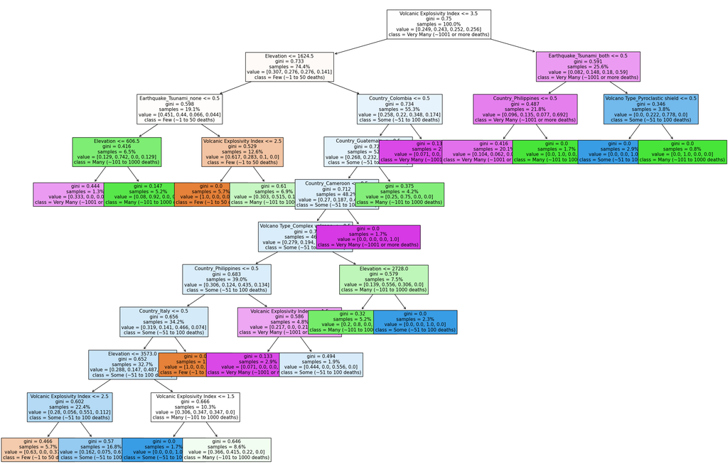

```python
plt.figure(figsize=(30,20))
plot_tree(decision_tree_model, filled='true', feature_names=decision_tree_model.feature_names_in_, class_names=decision_tree_model.classes_, proportion=True, fontsize = 11)
plt.show()
```

```python
rf = RandomForestClassifier(random_state = 25, max_depth=10, max_leaf_nodes= 20, min_samples_split=2) #60, 10, 5
X_train, X_test, y_train, y_test = train_test_split(
    X,
    y,
    test_size=0.4, #.8
    random_state=30) #15

rf.fit(X_train, y_train)
```

```
RandomForestClassifier(max_depth=10, max_leaf_nodes=20, random_state=25)
```

```python
categories = rf.classes_
predictions = rf.predict(X_test)
probabilities = rf.predict_proba(X_test)
probabilities = pd.DataFrame(probabilities,
                    columns=categories)
probabilities
```

|  | Few (~1 to 50 deaths) | Many (~101 to 1000 deaths) | Some (~51 to 100 deaths) | Very Many (~1001 or more deaths) |
| --- | --- | --- | --- | --- |
| 0 | 0.253685 | 0.498515 | 0.141358 | 0.106442 |
| 1 | 0.554091 | 0.278690 | 0.107894 | 0.059325 |
| 2 | 0.159500 | 0.095122 | 0.652074 | 0.093304 |
| 3 | 0.261112 | 0.148806 | 0.402851 | 0.187231 |
| 4 | 0.159500 | 0.095122 | 0.652074 | 0.093304 |
| ... | ... | ... | ... | ... |
| 314 | 0.038414 | 0.141249 | 0.081334 | 0.739002 |
| 315 | 0.398411 | 0.238076 | 0.234893 | 0.128620 |
| 316 | 0.122441 | 0.046238 | 0.084484 | 0.746837 |
| 317 | 0.365555 | 0.455317 | 0.136941 | 0.042187 |
| 318 | 0.144956 | 0.735845 | 0.034468 | 0.084731 |

319 rows × 4 columns

```python
fi = pd.DataFrame({'col_name': rf.feature_importances_}, index=X.columns).sort_values(by='col_name', ascending=False)
fi = fi[fi.col_name > 0.028]
fi
```

|  | col_name |
| --- | --- |
| Volcanic Explosivity Index | 0.198544 |
| Elevation | 0.191060 |
| Earthquake_Tsunami_none | 0.060070 |
| Earthquake_Tsunami_Tsunami | 0.044019 |
| Volcano Type_Stratovolcano | 0.036781 |
| Volcano Type_Complex volcano | 0.036057 |
| Country_Colombia | 0.035679 |
| Country_Japan | 0.030708 |
| Earthquake_Tsunami_both | 0.029842 |
| Country_Indonesia | 0.028512 |

```python
# Calculate confusion matrix and transform data
conf_mat = confusion_matrix(y_test,predictions)
conf_mat = pd.DataFrame(conf_mat,index=categories,columns=categories)
conf_mat = conf_mat.melt(ignore_index=False).reset_index()
# Create heatmap
heatmap = alt.Chart(conf_mat, title="Confusion Matrix").mark_rect().encode(
    x=alt.X("variable:N", sort=['Few (~1 to 50 deaths)','Some (~51 to 100 deaths)','Many (~101 to 1000 deaths)','Very Many (~1001 or more deaths)']).title("Predicted Response"),
    y=alt.Y("index:N", sort=['Few (~1 to 50 deaths)','Some (~51 to 100 deaths)','Many (~101 to 1000 deaths)','Very Many (~1001 or more deaths)']).title("True Response"),
    color=alt.Color("value:Q", legend=None).scale(scheme="cividis")
).properties(
    width=400,
    height=400
)
# Add text labels for numbers
text = heatmap.mark_text(baseline="middle").encode(
    text=alt.Text("value:Q"),
     color=alt.condition(
        (alt.datum['value'] < 30),
        alt.value('white'),
        alt.value('black')
    ),
    size=alt.value(50)
)

heatmap + text
```

[interactive chart not shown]

This confusion matrix shows all of the predicted responses from our model compared to the correct categories that come from our testing data. A good confusion matrix would have all of the responses in the diagonal from the top left corner to the bottom right. My confusion matrix does a very good job at that. My confusion matrix shows that my model predicted the right category 260 times out of 319, and predicted wrong only 59 times out of 319 times. This shows that my model is very accurate, but still predicts wrong sometimes. This matrix also shoes me that the model is a little less confident in predicting the "Few (~1 to 50 deaths)" category because it has a lot of missed predictions in the same row. Overall, this confusion matrix shows that my model is very accurate.

```python
# found idxmax from: https://stackoverflow.com/questions/29919306/find-the-column-name-which-has-the-maximum-value-for-each-row
pred = probabilities.copy()
pred['MaxPred'] = pred.max(axis=1)

predHist = alt.Chart(pred, title='Prediction Percentage Distribution').mark_bar().encode(
    x = alt.X('MaxPred:Q', title='Prediction Percentage').bin(maxbins=10),
    y = alt.Y('count():Q')
).properties(
    height=400,
    width=300
)
predHist
```

[interactive chart not shown]

```python
print(classification_report(y_test, predictions))
```

```
                                  precision    recall  f1-score   support

           Few (~1 to 50 deaths)       0.91      0.62      0.74        80
      Many (~101 to 1000 deaths)       0.82      0.87      0.84        83
        Some (~51 to 100 deaths)       0.77      0.84      0.80        79
Very Many (~1001 or more deaths)       0.80      0.94      0.86        77

                        accuracy                           0.82       319
                       macro avg       0.82      0.82      0.81       319
                    weighted avg       0.82      0.82      0.81       319
```

In the classification report shown, you can see that our model is 82% accurate. The precision scores all showed my model to be an accurate model with scores of 77% and above, which shows that when my model predicts a category, it is correct 77% of the time. My model has recall scores of above 84%, except for the "Few (1 to 50 deaths)", which is 62%, which means that I am only correct at predicting that category 62% of the time. This means that my model is very good at predicting the categories, but is a little confused when predicting the "Few (1 to 50 deaths)" category. The accuracy score was very good at an 82%, which is a good accuracy overall. Overall, these scores indicate that my model is very good at predicting the range of deaths that will occur from an eruption, but can get a little confused when predicting the "Few (~1 to 50 deaths)" category.

```python
# I got the sort from: github.com/vega/altair/issues/1137
heatmap2 = alt.Chart(data, title="Deaths Range Per Explosivity Index").mark_rect().encode(
    x=alt.X("Tot_Deaths_Range:N", sort=['Few (~1 to 50 deaths)','Some (~51 to 100 deaths)','Many (~101 to 1000 deaths)','Very Many (~1001 or more deaths)']).title("Deaths Range"),
    y=alt.Y("Volcanic Explosivity Index").bin(maxbins=8),
    color=alt.Color("count():Q", legend=None).scale(scheme="cividis")
).properties(
    width=400,
    height=400
)

text2 = heatmap2.mark_text(baseline="middle").encode(
    text=alt.Text("count():Q"),
     color=alt.condition(
        (alt.datum['count():Q'] < 30),
        alt.value('white'),
        alt.value('black')
    ),
    size=alt.value(50)
)
heatmap2 + text2
```

[interactive chart not shown]

Lastly, here is a heatmap of the counts of the volcanic explosivity index versus the deaths range of volcanic explosions. Excluding the "Few (1 to 50 deaths)" category, we can see that as the range of deaths goes up, the counts of higher explosivity indexes typically is higher than the lower death ranges, and the counts of lower indexes goes is higher for smaller death ranges. This shows the generic correlation of explosivity index versus death that we explored previously. My model showed that it struggled with predicting the "Few (1 to 50 deaths)" category, and I think `this model supports my hypothesis that it has to do with the population density around a volcano, and that is the missing predictor in our model`. As we can see, there are high counts of few deaths for the explosity indexes 5 and 6, `I hypothesize that this is due to there not being many people around the volcano to be affected by the natural disaster, which would explain why there would be few deaths that occurred from the eruption`.

## Conclusion

In the end, there were clear patterns in the volcanoes dataset that allowed us to predict the range of deaths that will occur from volcanic eruptions. Overall the most predictive predictor was the volcanic explosivity index followed by the volcano evelation, earthquakes and tsunamis, and the country of the eruption. I was also able to prove my hypothesis through hypothesis testing, that it was statistically significant that, and not up to random chance, that more deaths resulted from volcanic eruptions in the past then they do today. Which signaled that we have learned more about volcanoes and have learned how to better deal with them. Through my exploritory data analysis, I was able to pick up on the patterns that the volcanic explosivity index, volcano type, country, and the year all correlated with the number of deaths that resulted from that eruption, but they never seemed fully accurate, for their data sometimes varried. This is when I hypothesized that there could be another predictor that could help with the correlations. I hypothesized that the missing data piece was the population density surrounding the volcano, because an eruption with an explosivity index could occur in the middle of nowhere with nobody around to be affected by it. This is why I believe my accuracy in predicting the few deaths category is messed up, because without the population density factor going into concideration, my model will predict eruptions of higher death counts. The only issue was, that I didn't have access to data that was that precise for the number of eruptions I needed for my random forest classifier model.

This problem was tackled within the [Journal of Applied Volcanology](https://appliedvolc.biomedcentral.com/articles/10.1186/s13617-017-0067-4#citeas). Their model was very similar to mine, but instead of predicting the range of deaths that resulted in a volcano, they predicted the percent chance that a person would survive a volcano. In their models the predictors they used that were similar to mine were the volcanic explosivity index, volcano type/volcano hazards, earthquakes, and tsunamis. Their dataset also held the distance away from the volcano, which was not in their dataset, and is what would be the equivalent of a population density of a distance surrounding a volcano for my model. Their findings were very similar to mine in every category. In future analysis, I would suggest that a population density surrounding the volcano be added for as many eruptions we can find. That would allow the model to become less confused when predicting the few deaths category.

Overall, even without the population density predictior, my model of a random forest classifier performed really well with an 82% accuracy rate to predict the range of deaths that would result from a volcanic eruption. In my random forest classifier, I used the data that was past the year 1900 becuase my hypothesis test stated that the number of deaths that occured before that was statistically significantly higher than the recent eruptions, which would possibly confuse my model if I kept it in. This worked really well, and I believe this makes my model more relevant to future eruptions. In future studies, I may work with the coordinates data included in the `significant-volcanic-eruption-database.csv` to find population densities around a volcano and if I can, I can record the population densities myself for future eruptions in order to make a better model. In all, I feel like I learned a lot about volcanoes and what makes them such a disasterous natural disaster, and I feel like my model can help predict future eruption deaths as well.

Brown, S.K., Jenkins, S.F., Sparks, R.S.J. et al. "Volcanic fatalities database: analysis of volcanic threat with distance and victim classification." *Journal of Applied Volcanology*, 20 Sept. 2017, https://doi.org/10.1186/s13617-017-0067-4